# Enron Fraud

Student response addresses the most important characteristics of the dataset and uses these characteristics to inform their analysis. Important characteristics include:

total number of data points allocation across classes (POI/non-POI) number of features used are there features with many missing values? etc. The rubric requires to address the most important characteristics of the dataset and to use these characteristics to inform the analysis. Please make sure your discussion considers:

The total number of data points. The allocation across classes (POI/non-POI). The number of features used. Optionally: The distribution of missing values in the features: How many missing values are there for each feature? How are you dealing with missing values? Please note that the Tester.py function automatically converts all missing values to 0.

```python
#!/usr/bin/python
from IPython.core.display import HTML
HTML("""
<style>
.output_png {
    display: table-cell;
    text-align: center;
    vertical-align: middle;
}
</style>
""")

import warnings
warnings.filterwarnings('ignore')

%matplotlib inline
import sys
import pickle
import seaborn as sns
import pandas as pd
import numpy as np
import matplotlib.pyplot as plt

sys.path.append("../tools/")

#utilities
from sklearn.decomposition import PCA
from sklearn.pipeline import Pipeline
from sklearn.metrics import precision_recall_fscore_support, precision_score
from sklearn.feature_selection import SelectKBest, chi2, SelectPercentile
from sklearn.model_selection import train_test_split, GridSearchCV, KFold
from sklearn.preprocessing import MinMaxScaler
from sklearn.cross_validation import StratifiedKFold
from sklearn.feature_selection import RFECV

#classifiers
from sklearn.naive_bayes import GaussianNB
from sklearn.neighbors import KNeighborsClassifier
from sklearn.svm import SVC
from sklearn.tree import DecisionTreeClassifier
from sklearn.cluster import KMeans
from sklearn.ensemble import RandomForestClassifier, AdaBoostClassifier
from feature_format import featureFormat, targetFeatureSplit
from tester import dump_classifier_and_data, test_classifier
from poi_email_addresses import poiEmails
```

### Available Features

financial features: ['salary', 'deferral_payments', 'total_payments', 'loan_advances', 'bonus', 'restricted_stock_deferred', 'deferred_income', 'total_stock_value', 'expenses', 'exercised_stock_options', 'other', 'long_term_incentive', 'restricted_stock', 'director_fees'] (all units are in US dollars)

email features: ['to_messages', 'email_address', 'from_poi_to_this_person', 'from_messages', 'from_this_person_to_poi', 'shared_receipt_with_poi'] (units are generally number of emails messages; notable exception is ‘email_address’, which is a text string)

POI label: [‘poi’] (boolean, represented as integer)

```python
### Task 1: Select what features you'll use.
### features_list is a list of strings, each of which is a feature name.
### The first feature must be "poi".
features_list = ['poi',
                 'salary',
                 'deferral_payments',
                 'total_payments',
                 'loan_advances',
                 'bonus',
                 'restricted_stock_deferred',
                 'deferred_income',
                 'total_stock_value',
                 'expenses',
                 'exercised_stock_options',
                 'other',
                 'long_term_incentive',
                 'restricted_stock',
                 'director_fees',
                 'from_messages',
                 'to_messages',
                 'from_this_person_to_poi',
                 'from_poi_to_this_person',
                 'shared_receipt_with_poi']

# You will need to use more features

### Load the dictionary containing the dataset
with open("final_project_dataset.pkl", "r") as data_file:
    data_dict = pickle.load(data_file)
```

```python
### Task 2: Remove outliers
### We drop the outliers we already know to exist from the course, like TOTAL, and others we've found by visual inspection
for outlier in ["LOCKHART EUGENE E", "TOTAL", "THE TRAVEL AGENCY IN THE PARK"]:
    if outlier in data_dict:
        data_dict.pop(outlier)

### Conversion to pandas.dataframe for easy aggregation, cleaning, and detection of outliers
df = pd.DataFrame.from_dict(data_dict)

### We keep only the features we've chosen
df = df.transpose()[features_list]

### Seeing that all of the booleans and NaN's are actually strings, we convert them to appropriate
### objects
df.replace("NaN", np.nan, inplace=True)
df.replace("False", False, inplace=True)
df.replace("True", True, inplace=True)
print "The total number of NaN's in this data set of %d features is %d." \
%(len(features_list), df.isnull().values.sum())
```

```
The total number of NaN's in this data set of 20 features is 1282.
```

### More basic facets of the data set

```python
print "The number of \"POIs\" and \"non-POIs\" are %s and %s, respectively, out of %s listed individuals.\n" \
%(sum(df["poi"]==True), sum(df["poi"]==False), df.shape[0])

print "As for the distribution of NaNs across features that have them, we can see this in the following table:"
print df.shape[0]-df.describe().loc["count"]
```

```
The number of "POIs" and "non-POIs" are 18 and 125, respectively, out of 143 listed individuals.

As for the distribution of NaNs across features that have them, we can see this in the following table:
salary                        49.0
deferral_payments            105.0
total_payments                20.0
loan_advances                140.0
bonus                         62.0
restricted_stock_deferred    126.0
deferred_income               95.0
total_stock_value             18.0
expenses                      49.0
exercised_stock_options       42.0
other                         52.0
long_term_incentive           78.0
restricted_stock              34.0
director_fees                127.0
from_messages                 57.0
to_messages                   57.0
from_this_person_to_poi       57.0
from_poi_to_this_person       57.0
shared_receipt_with_poi       57.0
Name: count, dtype: float64
```

```python
### Let's look at the distribution of values across the two classes
print "Here is the distribution of filled values (not NaNs) by POI status:\n"
df.groupby("poi").count().transpose()
```

```
Here is the distribution of filled values (not NaNs) by POI status:
```

| poi | False | True |
| --- | --- | --- |
| salary | 77 | 17 |
| deferral_payments | 33 | 5 |
| total_payments | 105 | 18 |
| loan_advances | 2 | 1 |
| bonus | 65 | 16 |
| restricted_stock_deferred | 17 | 0 |
| deferred_income | 37 | 11 |
| total_stock_value | 107 | 18 |
| expenses | 76 | 18 |
| exercised_stock_options | 89 | 12 |
| other | 73 | 18 |
| long_term_incentive | 53 | 12 |
| restricted_stock | 92 | 17 |
| director_fees | 16 | 0 |
| from_messages | 72 | 14 |
| to_messages | 72 | 14 |
| from_this_person_to_poi | 72 | 14 |
| from_poi_to_this_person | 72 | 14 |
| shared_receipt_with_poi | 72 | 14 |

```python
to_drop = ['director_fees', 'restricted_stock_deferred', 'loan_advances']
for col in df.columns:
    if col in to_drop:
        df.drop(col, axis=1,inplace=True)

### update the features list as well
for feature in to_drop:
    if feature in features_list:
        features_list.remove(feature)
print "What is this 'other' feature? Let's take a look:\n"
print df.other.head()
print "\nLooks like uncategorized income with a huge range."
```

```
What is this 'other' feature? Let's take a look:

ALLEN PHILLIP K           152.0
BADUM JAMES P               NaN
BANNANTINE JAMES M     864523.0
BAXTER JOHN C         2660303.0
BAY FRANKLIN R             69.0
Name: other, dtype: float64

Looks like uncategorized income with a huge range.
```

```python
### We make a plotting function, which can further help with outlier detection

def plot_features(df, features, logx=False, logy=False):
    # initial plt figure settings
    plt.figure(figsize = (9, 6))
    #recasting features for indexing, to support tuple as input
    features = list(features)
    f1 = df[features[0]]
    f2 = df[features[1]]
    if logx:
        plt.xscale("log")
        features[0] = features[0] + " (log10)"
    if logy:
        plt.yscale("log")
        features[1] = features[1] + " (log10)"
    if len(features) == 2:
        plt.scatter(x=f1, y=f2)
    else:
        f3 = df[features[2]]
        for i in range(len(f3)):
            if f3[i] == 0:
                plt.scatter(x = f1[i], y = f2[i], color="b")
            else:
                plt.scatter(x = f1[i], y = f2[i], marker='x')

    plt.xlabel(features[0])
    plt.ylabel(features[1])

    plt.show()
```

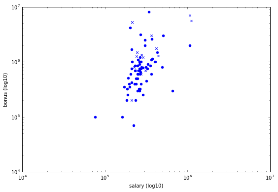

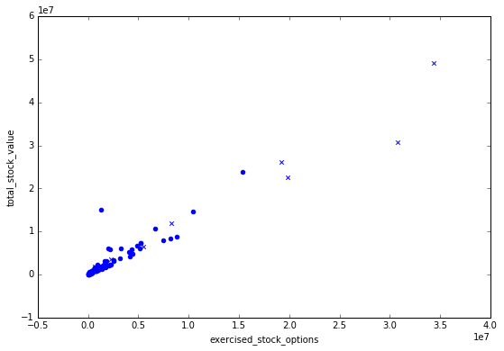

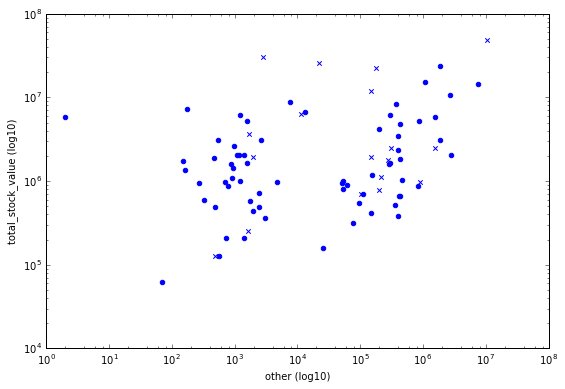

```python
##Outlier detection through visualizations
plot_features(df, ("salary", "bonus", "poi"), True, True)
plot_features(df, ("exercised_stock_options", "total_stock_value", "poi"), False, False)
plot_features(df, ["other", "total_stock_value", "poi"], True, True)
```

```python
#outlier removal with a threshold function
def remove_outliers(df, feature=None, q = 0.99):
    q = df[feature].quantile(q)
    return df[df[feature]< q]
```

## Feature Selection and Scaling

```python
###select, scale, and update my_dataset with selected features

### First, scaler can't handle NaN's, so we must impute values for them
### We try to do this with Pandas' built-in functions
### NB: I first attempted this with the sklearn.preprocessing.Imputer class, but
### the output invariably ended up with conflicting lengths--values were being dropped,
### perhaps due to use of a pandas series object rather than a numpy array.


for feature in df.columns:
    df[feature].fillna(0, inplace=True)

scaler = MinMaxScaler()

df_scaled = df.copy()
df_scaled[df.columns] = scaler.fit_transform(df[df.columns])
```

```
Optimal number of features : 5
[ True False False False False False  True  True  True False False False
 False  True False False]
AdaBoostClassifier(algorithm='SAMME.R', base_estimator=None,
          learning_rate=1.0, n_estimators=50, random_state=None)
```

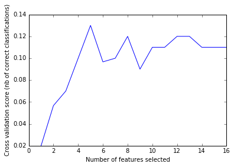

```
Optimal number of features : 6
[False False  True  True False False False  True  True False  True False
 False False False  True]
DecisionTreeClassifier(class_weight=None, criterion='gini', max_depth=None,
            max_features=None, max_leaf_nodes=None,
            min_impurity_split=1e-07, min_samples_leaf=1,
            min_samples_split=2, min_weight_fraction_leaf=0.0,
            presort=False, random_state=None, splitter='best')
```

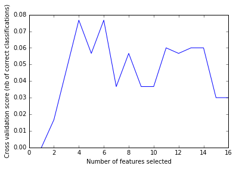

```
Optimal number of features : 4
[ True False False  True False  True False  True False False False False
 False False False False]
RandomForestClassifier(bootstrap=True, class_weight=None, criterion='gini',
            max_depth=None, max_features='auto', max_leaf_nodes=None,
            min_impurity_split=1e-07, min_samples_leaf=1,
            min_samples_split=2, min_weight_fraction_leaf=0.0,
            n_estimators=10, n_jobs=1, oob_score=False, random_state=None,
            verbose=0, warm_start=False)
```

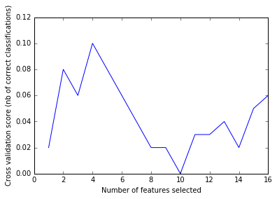

```python
### convert df to dictionary with appropriate keys (names of people)
my_dataset = df_scaled.to_dict(orient = "index")

### Extract features and labels from dataset for local testing
data = featureFormat(my_dataset, features_list, sort_keys = True)

labels, features = targetFeatureSplit(data)

for i in range(len(labels)):
    labels[i] = int(labels[i])

classifiers = [AdaBoostClassifier(),
               DecisionTreeClassifier(class_weight=None),
               RandomForestClassifier(class_weight=None)
              ]

for clf in classifiers:
    rfecv = RFECV(estimator=clf, step=1, cv=StratifiedKFold(labels, 50),
              scoring='precision')
    rfecv.fit(features, labels)
    print "Optimal number of features : %d" % rfecv.n_features_
    print rfecv.support_
    print type(clf)
    # Plot number of features VS. cross-validation scores
    plt.figure()
    plt.xlabel("Number of features selected")
    plt.ylabel("Cross validation score (nb of correct classifications)")
    plt.plot(range(1, len(rfecv.grid_scores_) + 1), rfecv.grid_scores_)
    plt.show()
```

We take a hint from the recursive feature selection applied above, and use KBest to extract the suggested number of features for each classifier.

```python
### We create a graphing function that can evalute the effect of k in KBest on basic fit score of classifiers

def graph_k_accuracy(kvalues = 1, clfs = []):
    for clf in clfs:
        plt.figure()
        plt.xlabel("Number of KBest Features Used")
        plt.ylabel("Accuracy of classifier")
        scores = []
        for k in range(1, kvalues + 1):
            kbest = SelectKBest(k=k)
            scaled_K = kbest.fit_transform(features, labels)
            features_train, features_test, labels_train, labels_test = \
            train_test_split(scaled_K, labels, test_size = 0.3)
            scores.append(clf.fit(features_train, labels_train).score(features_test, labels_test))
        plt.plot(range(1, kvalues + 1), scores)
        plt.show()
```

```python
# split data
features_train, features_test, labels_train, labels_test = \
    train_test_split(features, labels, test_size = 0.3, random_state = 42)
```

```python
### Task 4: Try a varity of classifiers
### Please name your classifier clf for easy export below.
### Note that if you want to do PCA or other multi-stage operations,
### you'll need to use Pipelines. For more info:
### http://scikit-learn.org/stable/modules/pipeline.htm

###AdaBoost trial

param_grid = [{'ada__n_estimators':[10, 50],
             'ada__learning_rate':[0.25,1.0],
             'skb__k': [5,8]
              }]

pipe = Pipeline(steps=[("skb", SelectKBest()),("ada", AdaBoostClassifier())])

clf = GridSearchCV(pipe, param_grid)
test_classifier(clf, my_dataset, features_list, folds = 1000)
```

```
GridSearchCV(cv=None, error_score='raise',
       estimator=Pipeline(steps=[('skb', SelectKBest(k=10, score_func=<function f_classif at 0x000000000C5E5358>)), ('ada', AdaBoostClassifier(algorithm='SAMME.R', base_estimator=None,
          learning_rate=1.0, n_estimators=50, random_state=None))]),
       fit_params={}, iid=True, n_jobs=1,
       param_grid=[{'skb__k': [5, 8], 'ada__n_estimators': [10, 50], 'ada__learning_rate': [0.25, 1.0]}],
       pre_dispatch='2*n_jobs', refit=True, return_train_score=True,
       scoring=None, verbose=0)
	Accuracy: 0.86633	Precision: 0.49553	Recall: 0.13850	F1: 0.21649	F2: 0.16182
	Total predictions: 15000	True positives:  277	False positives:  282	False negatives: 1723	True negatives: 12718
```

```python
### DecisionTree trial

tree_grid = [{'tree__class_weight' : ['balanced', None],
              'tree__max_depth' : [100, 50, 25],
              'tree__max_leaf_nodes' : [None, 10, 25, 50],
              'skb__k': [4,6]}]

pipe = Pipeline(steps=[("skb", SelectKBest()), ("tree", DecisionTreeClassifier())])

clf = GridSearchCV(pipe, param_grid=tree_grid)

test_classifier(clf, my_dataset, features_list, folds = 1000)
```

```
GridSearchCV(cv=None, error_score='raise',
       estimator=Pipeline(steps=[('skb', SelectKBest(k=10, score_func=<function f_classif at 0x000000000C5E5358>)), ('tree', DecisionTreeClassifier(class_weight=None, criterion='gini', max_depth=None,
            max_features=None, max_leaf_nodes=None,
            min_impurity_split=1e-07, min_samples_leaf=1,
            min_samples_split=2, min_weight_fraction_leaf=0.0,
            presort=False, random_state=None, splitter='best'))]),
       fit_params={}, iid=True, n_jobs=1,
       param_grid=[{'tree__max_depth': [100, 50, 25], 'skb__k': [4, 6], 'tree__max_leaf_nodes': [None, 10, 25, 50], 'tree__class_weight': ['balanced', None]}],
       pre_dispatch='2*n_jobs', refit=True, return_train_score=True,
       scoring=None, verbose=0)
	Accuracy: 0.81013	Precision: 0.26600	Recall: 0.24100	F1: 0.25289	F2: 0.24562
	Total predictions: 15000	True positives:  482	False positives: 1330	False negatives: 1518	True negatives: 11670
```

```python
K_best = clf.best_estimator_.named_steps['skb']
print clf.best_estimator_

features_scores = zip(K_best.scores_, features_list[1:])
features_scores = sorted(features_scores, key = lambda x: x[0], reverse=True)
for i, j in features_scores:
    print '%.2f' %i, j
```

```
Pipeline(steps=[('skb', SelectKBest(k=6, score_func=<function f_classif at 0x000000000C5E5358>)), ('tree', DecisionTreeClassifier(class_weight='balanced', criterion='gini',
            max_depth=50, max_features=None, max_leaf_nodes=None,
            min_impurity_split=1e-07, min_samples_leaf=1,
            min_samples_split=2, min_weight_fraction_leaf=0.0,
            presort=False, random_state=None, splitter='best'))])
14.69 total_stock_value
13.71 exercised_stock_options
11.20 salary
11.13 bonus
6.58 restricted_stock
5.91 expenses
5.50 shared_receipt_with_poi
5.30 deferred_income
3.59 from_poi_to_this_person
2.77 total_payments
2.61 long_term_incentive
2.14 from_this_person_to_poi
0.68 to_messages
0.26 deferral_payments
0.17 from_messages
0.01 other
```

```python
### RandomForest Trial

### I choose k values reflecting the highest peaks in the above performance vs k-value graphs, and as
### the runtime on this is already enormous without testing for every possible k-value
forest_grid = [{'forest__class_weight' : [None, 'balanced'],
                'forest__criterion':['gini', 'entropy'],
                'forest__max_depth':[None],
                'skb__k': [4],
                }]

pipe = Pipeline(steps=[("skb", SelectKBest()),("forest", RandomForestClassifier())])

clf = GridSearchCV(pipe, param_grid=forest_grid)

test_classifier(clf, my_dataset, features_list, folds = 1000)
```

```
GridSearchCV(cv=None, error_score='raise',
       estimator=Pipeline(steps=[('skb', SelectKBest(k=10, score_func=<function f_classif at 0x000000000C5E5358>)), ('forest', RandomForestClassifier(bootstrap=True, class_weight=None, criterion='gini',
            max_depth=None, max_features='auto', max_leaf_nodes=None,
            min_impurity_split=1e-...mators=10, n_jobs=1, oob_score=False, random_state=None,
            verbose=0, warm_start=False))]),
       fit_params={}, iid=True, n_jobs=1,
       param_grid=[{'forest__class_weight': [None, 'balanced'], 'skb__k': [4], 'forest__max_depth': [None], 'forest__criterion': ['gini', 'entropy']}],
       pre_dispatch='2*n_jobs', refit=True, return_train_score=True,
       scoring=None, verbose=0)
	Accuracy: 0.85820	Precision: 0.42131	Recall: 0.17000	F1: 0.24225	F2: 0.19303
	Total predictions: 15000	True positives:  340	False positives:  467	False negatives: 1660	True negatives: 12533
```

## Classifier performance reevaluated, with the addition of some custom features

Now, I add a few new features, and we test the performance of the classifiers with these additions. Hopefully, they are an improvement.

```python
### Task 3: Create new feature(s)

### As suggested in the quizzes, I will make a ratio of to/from POI : total emails.
### It stands to reason that POIs communicate together with greater relative frequency.
df_scaled["to_poi_ratio"] = df_scaled["from_poi_to_this_person"] / df_scaled["to_messages"]
df_scaled["from_poi_ratio"] = df_scaled["from_this_person_to_poi"]/df_scaled['from_messages']

###I add a similar feature, extending the logic to the email POIs were CC'ed on
df_scaled["receipt_with_poi_ratio"] = df_scaled["shared_receipt_with_poi"]/df_scaled['from_messages']

#add our new features to the features list
features_list.append("to_poi_ratio")
features_list.append("from_poi_ratio")
features_list.append("receipt_with_poi_ratio")

#NaNs introduced, and targetFeatureSplit fails to replace them with 0's as advertised
df_scaled.fillna(0, inplace=True)
df_scaled.replace(np.inf, 0, inplace=True)
```

```
Optimal number of features : 9
[ True False False False  True False  True  True  True False  True False
 False  True False False  True  True False] AdaBoostClassifier(algorithm='SAMME.R', base_estimator=None,
          learning_rate=1.0, n_estimators=50, random_state=None)
```

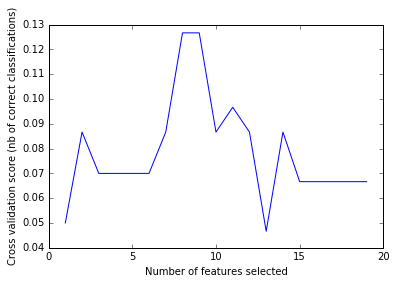

```
Optimal number of features : 19
[ True  True  True  True  True  True  True  True  True  True  True  True
  True  True  True  True  True  True  True] DecisionTreeClassifier(class_weight=None, criterion='gini', max_depth=None,
            max_features=None, max_leaf_nodes=None,
            min_impurity_split=1e-07, min_samples_leaf=1,
            min_samples_split=2, min_weight_fraction_leaf=0.0,
            presort=False, random_state=None, splitter='best')
```

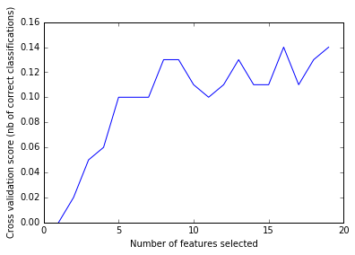

```
Optimal number of features : 9
[False False False  True  True  True  True  True  True False False False
 False False  True False False  True  True] RandomForestClassifier(bootstrap=True, class_weight=None, criterion='gini',
            max_depth=None, max_features='auto', max_leaf_nodes=None,
            min_impurity_split=1e-07, min_samples_leaf=1,
            min_samples_split=2, min_weight_fraction_leaf=0.0,
            n_estimators=10, n_jobs=1, oob_score=False, random_state=None,
            verbose=0, warm_start=False)
```

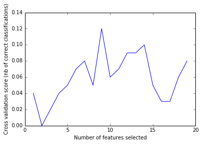

```python
### we recreate the data dictionary with the new features included
my_dataset = df_scaled.to_dict(orient = "index")

### Extract features and labels from dataset for local testing
data = featureFormat(my_dataset, features_list, sort_keys = True)

labels, features = targetFeatureSplit(data)

for i in range(len(labels)):
    labels[i] = int(labels[i])

classifiers = [AdaBoostClassifier(),
               DecisionTreeClassifier(class_weight=None),
               RandomForestClassifier(class_weight=None)
              ]

for clf in classifiers:
    rfecv = RFECV(estimator=clf, step=1, cv=StratifiedKFold(labels, 50),
              scoring='precision')
    rfecv.fit(features, labels)
    print "Optimal number of features : %d" % rfecv.n_features_
    print rfecv.support_, clf
    # features=features[:,rfecv.support_]
    # Plot number of features VS. cross-validation scores
    plt.figure()
    plt.xlabel("Number of features selected")
    plt.ylabel("Cross validation score (nb of correct classifications)")
    plt.plot(range(1, len(rfecv.grid_scores_) + 1), rfecv.grid_scores_)
    plt.show()
```

```python
#resplit the data with new features included
features_train, features_test, labels_train, labels_test = \
    train_test_split(features, labels, test_size = 0.3, random_state = 42)
```

```python
### Task 4 Trial 2: Try a varity of classifiers

###AdaBoost Re-Trial
ada_grid = [{'ada__n_estimators':[10, 50],
             'ada__learning_rate':[0.25,1.0],
             'skb__k': [6, 9, 14]
            }]

pipe = Pipeline(steps=[("skb", SelectKBest()),("ada", AdaBoostClassifier())])

clf = GridSearchCV(pipe, ada_grid)

test_classifier(clf, my_dataset, features_list, folds = 1000)
```

```
GridSearchCV(cv=None, error_score='raise',
       estimator=Pipeline(steps=[('skb', SelectKBest(k=10, score_func=<function f_classif at 0x000000000C5E5358>)), ('ada', AdaBoostClassifier(algorithm='SAMME.R', base_estimator=None,
          learning_rate=1.0, n_estimators=50, random_state=None))]),
       fit_params={}, iid=True, n_jobs=1,
       param_grid=[{'skb__k': [6, 9, 14], 'ada__n_estimators': [10, 50], 'ada__learning_rate': [0.25, 1.0]}],
       pre_dispatch='2*n_jobs', refit=True, return_train_score=True,
       scoring=None, verbose=0)
	Accuracy: 0.85973	Precision: 0.43580	Recall: 0.17650	F1: 0.25125	F2: 0.20034
	Total predictions: 15000	True positives:  353	False positives:  457	False negatives: 1647	True negatives: 12543
```

```python
### DT Re-Trial with new k value
tree_grid = [{'tree__class_weight' : [None, 'balanced'],
              'tree__max_depth' : [50],
              'tree__max_leaf_nodes' : [None],
              'skb__k': [8, 13, 19]}]

pipe = Pipeline(steps=[("skb", SelectKBest()), ("tree", DecisionTreeClassifier())])

clf = GridSearchCV(pipe, tree_grid)

test_classifier(clf, my_dataset, features_list, folds = 1000)
```

```
GridSearchCV(cv=None, error_score='raise',
       estimator=Pipeline(steps=[('skb', SelectKBest(k=10, score_func=<function f_classif at 0x000000000C5E5358>)), ('tree', DecisionTreeClassifier(class_weight=None, criterion='gini', max_depth=None,
            max_features=None, max_leaf_nodes=None,
            min_impurity_split=1e-07, min_samples_leaf=1,
            min_samples_split=2, min_weight_fraction_leaf=0.0,
            presort=False, random_state=None, splitter='best'))]),
       fit_params={}, iid=True, n_jobs=1,
       param_grid=[{'tree__max_depth': [50], 'skb__k': [8, 13, 19], 'tree__max_leaf_nodes': [None], 'tree__class_weight': [None, 'balanced']}],
       pre_dispatch='2*n_jobs', refit=True, return_train_score=True,
       scoring=None, verbose=0)
	Accuracy: 0.82773	Precision: 0.33778	Recall: 0.30400	F1: 0.32000	F2: 0.31020
	Total predictions: 15000	True positives:  608	False positives: 1192	False negatives: 1392	True negatives: 11808
```

```python
K_best = clf.best_estimator_.named_steps['skb']
print clf.best_estimator_

features_scores = zip(K_best.scores_, features_list[1:])
features_scores = sorted(features_scores, key = lambda x: x[0], reverse=True)
for i, j in features_scores:
    print '%.2f' %i, j
```

```
Pipeline(steps=[('skb', SelectKBest(k=8, score_func=<function f_classif at 0x000000000C5E5358>)), ('tree', DecisionTreeClassifier(class_weight='balanced', criterion='gini',
            max_depth=50, max_features=None, max_leaf_nodes=None,
            min_impurity_split=1e-07, min_samples_leaf=1,
            min_samples_split=2, min_weight_fraction_leaf=0.0,
            presort=False, random_state=None, splitter='best'))])
14.69 total_stock_value
13.71 exercised_stock_options
11.20 salary
11.13 bonus
8.24 from_poi_ratio
6.58 restricted_stock
5.91 expenses
5.50 shared_receipt_with_poi
5.30 deferred_income
3.59 from_poi_to_this_person
2.77 total_payments
2.61 long_term_incentive
2.43 receipt_with_poi_ratio
2.35 to_poi_ratio
2.14 from_this_person_to_poi
0.68 to_messages
0.26 deferral_payments
0.17 from_messages
0.01 other
```

```python
### RandomForest Re-Trial with new k-value and new features
### We learn from the previous iteration some of the parameters that seem to work best

forest_grid = [{'forest__class_weight' : [None],
                'forest__criterion':['gini'],
                'forest__max_depth':[None],
                'forest__n_estimators': [10],
                'skb__k': [9],
                }]

pipe = Pipeline(steps=[("skb", SelectKBest()),("forest", RandomForestClassifier())])

clf = GridSearchCV(pipe, param_grid=forest_grid)

test_classifier(clf, my_dataset, features_list, folds = 1000)
```

[output not shown]

```python
### Task 5: Tune your classifier to achieve better than .3 precision and recall
### using our testing script. Check the tester.py script in the final project
### folder for details on the evaluation method, especially the test_classifier
### function. Because of the small size of the dataset, the script uses
### stratified shuffle split cross validation. For more info:
### http://scikit-learn.org/stable/modules/generated/sklearn.cross_validation.StratifiedShuffleSplit.html

tree_grid = [{'tree__class_weight' : ['balanced'],
              'tree__max_depth' : [50],
              'tree__max_leaf_nodes' : [None],
              'skb__k': [19]
             }]

pipe = Pipeline(steps = [('skb', SelectKBest()), ('tree', DecisionTreeClassifier())])

clf = GridSearchCV(pipe, param_grid = tree_grid)

test_classifier(clf, my_dataset, features_list, folds = 1000)
```

```
GridSearchCV(cv=None, error_score='raise',
       estimator=Pipeline(steps=[('skb', SelectKBest(k=10, score_func=<function f_classif at 0x000000000C5E5358>)), ('tree', DecisionTreeClassifier(class_weight=None, criterion='gini', max_depth=None,
            max_features=None, max_leaf_nodes=None,
            min_impurity_split=1e-07, min_samples_leaf=1,
            min_samples_split=2, min_weight_fraction_leaf=0.0,
            presort=False, random_state=None, splitter='best'))]),
       fit_params={}, iid=True, n_jobs=1,
       param_grid=[{'tree__max_depth': [50], 'skb__k': [19], 'tree__max_leaf_nodes': [None], 'tree__class_weight': ['balanced']}],
       pre_dispatch='2*n_jobs', refit=True, return_train_score=True,
       scoring=None, verbose=0)
	Accuracy: 0.83773	Precision: 0.39139	Recall: 0.39100	F1: 0.39120	F2: 0.39108
	Total predictions: 15000	True positives:  782	False positives: 1216	False negatives: 1218	True negatives: 11784
```

```python
print clf.best_estimator_
```

[output not shown]

```python
### Task 6: Dump your classifier, dataset, and features_list so anyone can
### check your results. You do not need to change anything below, but make sure
### that the version of poi_id.py that you submit can be run on its own and
### generates the necessary .pkl files for validating your results.
dump_classifier_and_data(clf, my_dataset, features_list)
```